# Final Paper

STOR 320.002 Group 8

December 05, 2025

# INTRODUCTION

Obesity is a serious and costly chronic disease that affects more than two in five adults in the United States. Its consequences include increased risks of diabetes and cardiovascular disease, as well as a shorter life expectancy. Although obesity is often viewed as an individual health issue, research increasingly shows that people’s environments and economic circumstances play a significant role in shaping their diets and long-term health. Income, transportation access, and the types of food stores available in a community all influence daily choices in ways that extend beyond personal behavior. To study these structural influences, we use the USDA Food Environment Atlas. This national dataset provides detailed information on food outlet density, food access, demographics, and socioeconomic conditions across states. Because it combines environmental and economic measures, the dataset enables us to model how various aspects of the food environment relate to adult obesity rates.

Our first question addresses two variables related to access and income: **Can the availability of low-cost, low-nutrition retail options (e.g., dollar stores) be paired with income to predict adult obesity rates in a given state?** This question matters because not all food stores serve communities in the same way. Grocery stores and specialty markets offer healthier options, while dollar stores tend to stock inexpensive, highly processed foods and are often concentrated in lower-income areas. These differences can shape dietary patterns and may help explain why some communities experience higher obesity rates. To capture additional structural factors, we also include measures of food access, such as the percentage of residents who live far from a grocery store or who lack access to a vehicle. Limited physical access can push communities toward less nutritious options, even when healthier foods are available elsewhere. Income is also included because it shapes both affordability and the practicality of purchasing healthier foods.

The second question asks: **To what extent can race and age demographics predict adult obesity rates across U.S. states, and does prediction accuracy improve when both are included?** The significance of this question is that it answers questions about racial disparities when it comes to obesity, as obesity is not just a genetic and individual issue. This can answer questions regarding social and systemic factors and how racism and ageism can contribute to obesity rates. Understanding demographic predictors can uncover racial and age inequities. With this information, there can be a push to allocate resources that effectively meet demographic needs. Racial and age inequity impacts the economic well-being and public health of Americans as it may address concerns about discrimination, unequal access to resources and care, and socioeconomic disparities.

# DATA

This project uses data from the `USDA Food Environment Atlas`, a dataset published by the Economic Research Service within the United States Department of Agriculture. The Atlas compiles national, state, and county-level information on varying types of food accessibility across the United States. The version used in this project was last updated on April 21, 2025, and covers a wide range of indicators from 2012 to 2025. The data was split up across multiple spreadsheet tabs by superficial categories (i.e.: Access, Stores, Restaurants, etc.) Overall, the variables of interest that are investigated in this paper involve 1) information about the numerical density of varying types of food resources as a ratio to population density and 2) the percent of a specific demographic population that has “low access” to food stores.

| State | DSPTH20 | FFRPTH20 | GROCPTH20 | MEDHHINC21 | PCT_LACCESS_CHILD19 | PCT_LACCESS_HHNV19 | PCT_LACCESS_POP19 | PCT_LACCESS_SENIORS19 | PCT_OBESE_ADULTS22 | SPECSPTH20 |
| --- | --- | --- | --- | --- | --- | --- | --- | --- | --- | --- |
| AK | 0.124622754966667 | 0.7553831756 | 0.89954428565 | 70416.8 | 63.4839717185185 | 16.3269270057857 | 37.5365654071786 | 62.279480334 | 32.1 | 0.1007639912 |
| AL | 0.378805943432836 | 0.722819711854839 | 0.171403016188679 | 47976.0149253731 | 72.4888977504478 | 4.52709573580597 | 20.6219232265075 | 71.0100377780597 | 38.3 | 0.0519324737058824 |
| AR | 0.32655487756 | 0.603202937140845 | 0.207335998104167 | 46396.8133333333 | 69.2708424378667 | 4.09612146678667 | 25.3031944925067 | 70.054070282 | 37.4 | 0.0629367271111111 |
| AZ | 0.177668827866667 | 0.574446563357143 | 0.129345526214286 | 56644.3333333333 | 59.7103946693333 | 3.65891898873333 | 37.841310374 | 66.364088948 | 33.2 | 0.0547007316 |
| CA | 0.0744973308793103 | 0.729664274089286 | 0.252806195910714 | 75295.4310344828 | 39.490167405 | 1.55384542932759 | 20.8835844548793 | 44.7824834296207 | 28.1 | 0.0866915275416667 |
| CO | 0.1076393605625 | 0.912812847270833 | 0.274140400342105 | 66994.421875 | 55.7062137271875 | 1.87024959267187 | 26.3597148227812 | 56.2045870424844 | 25 | 0.1001662075 |
| CT | 0.0975977295 | 0.693922385625 | 0.1940713135 | 83967.75 | 54.32914829125 | 1.817389383875 | 28.87583887375 | 53.83441400625 | 30.6 | 0.06123448425 |
| DC | 0.037877936 | 1.160187244 | 0.245505154 | 91072 | 7.296584606 | 1.038527489 | 4.595057011 | 5.432554722 | 24.3 | 0.063129894 |
| DE | 0.150174384666667 | 0.747064352 | 0.164894516333333 | 69752.6666666667 | 53.13507716 | 2.017824928 | 26.2406673433333 | 51.0360018433333 | 37.9 | 0.074832807 |
| FL | 0.201568175059701 | 0.57627941721875 | 0.16549086737931 | 57613.5671641791 | 60.7441700043582 | 2.78000113858209 | 28.2124405787164 | 60.0811419767463 | 31.6 | 0.0663756671190476 |

[output cut: 41 more lines]

Above is a list of the variables of interest that are investigated in our first question. From left to right, the variables investigated in this question are: the number of dollar stores per 1,000 people in 2020, the number of fast-food restaurants per 1,000 people in 2020, the number of grocery stores per 1,000 people in 2020, the median household income in 2021, the percent of a population with children that have low access to a food store in 2019, the percent of a population with households with no car and low access to a food store in 2019, the percent of a population with low access to a food store in 2019, the percent of a population with seniors that have low access to a food store in 2019, the adult obesity rate percentage in 2022, and the number of specialized food stores per 1,000 people in 2020. Each variable was assigned a value within a state and specific county. The data was utilized as seen in the code setup below. Below is a list of variables investigated in our second question.

[output not shown]

[output cut: 41 more lines]

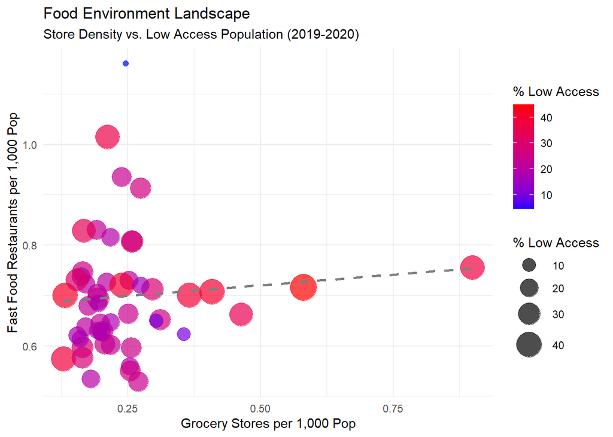

The next visualization displays the relationship between race and obesity levels.

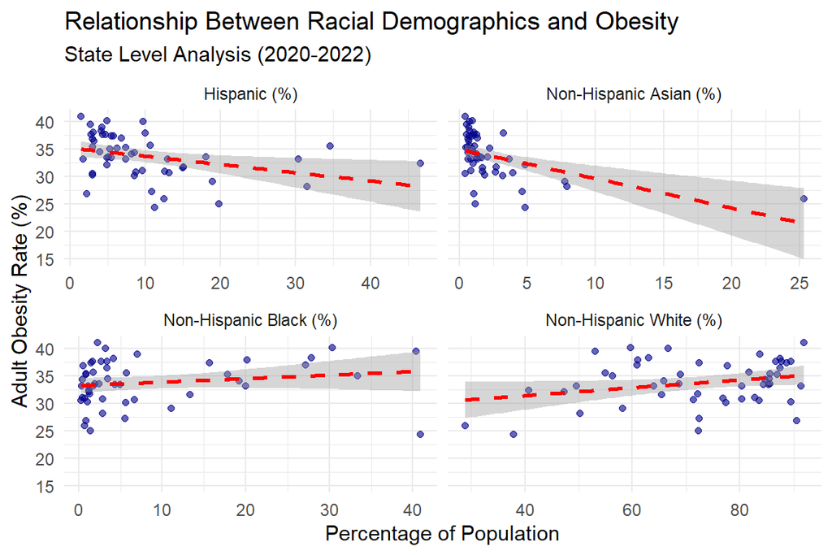

The figure indicates that states with higher populations of Hispanic or Non-Hispanic Asian populations tend to have lower obesity rates. There is an especially strong relationship between higher Non-Hispanic Asian populations and lower obesity rates. Conversely, the upwards slopes for Non-Hispanic Black and Non-Hispanic White populations indicate that states with higher Black or White populations tend to have higher obesity rates. Geographically, states in the West and Midwest tend to have higher Black or White populations, which can suggest that obesity rates in these areas will be higher. Additionally, being in sparsely populated areas in the West and the mountains can act as obstacles to easy access to healthy food options.

The next visualization displays the relationship between state, obesity levels, and income.

[interactive chart not shown]

As predicted in the previous visualization, the figure indicates that those in the West/Midwest tend to have higher obesity rates than those on the East and West coasts. States in the Midwest that are more geographically mountainous, remote, and with more spread out populations tend to have higher obesity rates. When hovering over each state, the average income is displayed on the map. The map shows that states with higher obesity rates tend to have lower average incomes compared to states with lower obesity rates. This visual shows that both geography and income are obstacles to accessing healthy and affordable food. Food accessibility, then, can be approached as an issue spurred by geography as well as socioeconomic differences.

# RESULTS

**QUESTION I**

For our first question, we were curious whether or not we could leverage income as well as the availability of low-cost, low-nutrition retail options to predict adult obesity rates within a given state. We approached this by selecting `8 variables` that related to food availability. 4 of these represented the quantities of different types of stores within a given area, and the remaining 4 were percentages encapsulating food access for different age demographics. We decided to use the caret package, a unified interface for fitting models using cross validation, to train our predictive model. After filtering the variables, handling missing values, and aggregating data into a new state level dataset consisting of our variables of choice, we were ready to begin training the model. We decided to create one model that only leveraged income to predict obesity rates, one model that leveraged both income and the food availability variables, and one model that leveraged both. To start, we constructed three predictor sets, X_food, X_income, and X_both. We then created a corresponding numeric vector Y that contained state level obesity rates. When training the model, we made sure to ensure cross-validation splits were the same each time it was run. We chose to use 5 folds, which means that the model was trained on ⅘ of the subsets of data and validated on the remaining ⅕. This process is repeated for all possible groups of 4. For the method, we used a linear regression model, which computes metrics like R², the coefficient of determination, and RMSE, which represents the average magnitude of the errors between the fitted and actual values in the model.

```
## # A tibble: 3 × 3
##   Model                  RMSE    R2
##   <chr>                 <dbl> <dbl>
## 1 Food Environment Only  3.04 0.436
## 2 Income Only            2.86 0.537
## 3 Combined Model         3.25 0.444
```

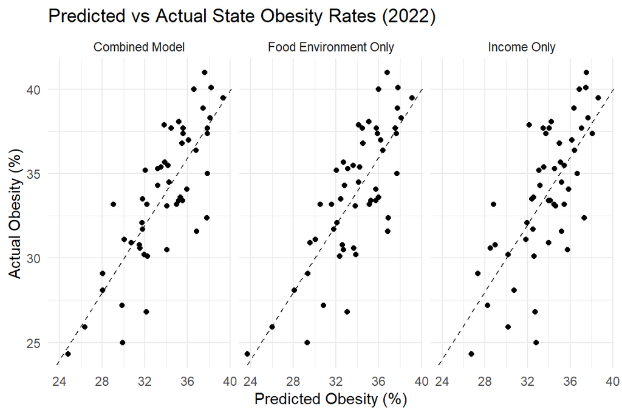

After fitting and comparing the three models, we found that the income only model was the most efficient, with an `RMSE of 2.86` and an `R² of 0.537`. Since we initially assumed the combined model would be most efficient, we decided to see if any of the 8 variables within the food-environment model were hurting the efficiency of the model. To evaluate this, we leveraged the GLMNET package to run a lasso regression model, assigning lasso coefficients to each variable. The magnitude of the lasso coefficient determines how strong of a correlation each variable has to obesity rates. After running this, we found that the percentage variables all had very small coefficients, while the store density variables were much more strongly correlated. Specialized food stores per 1,000 and Dollar Stores per 1000 had the highest values.

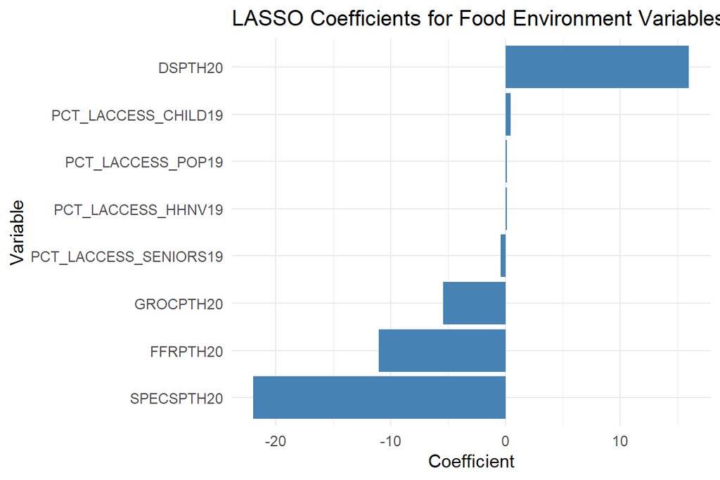

```
## # A tibble: 3 × 3
##   Model                  RMSE    R2
##   <chr>                 <dbl> <dbl>
## 1 Food Environment Only  3.03 0.484
## 2 Income Only            2.86 0.537
## 3 Combined Model         2.71 0.545
```

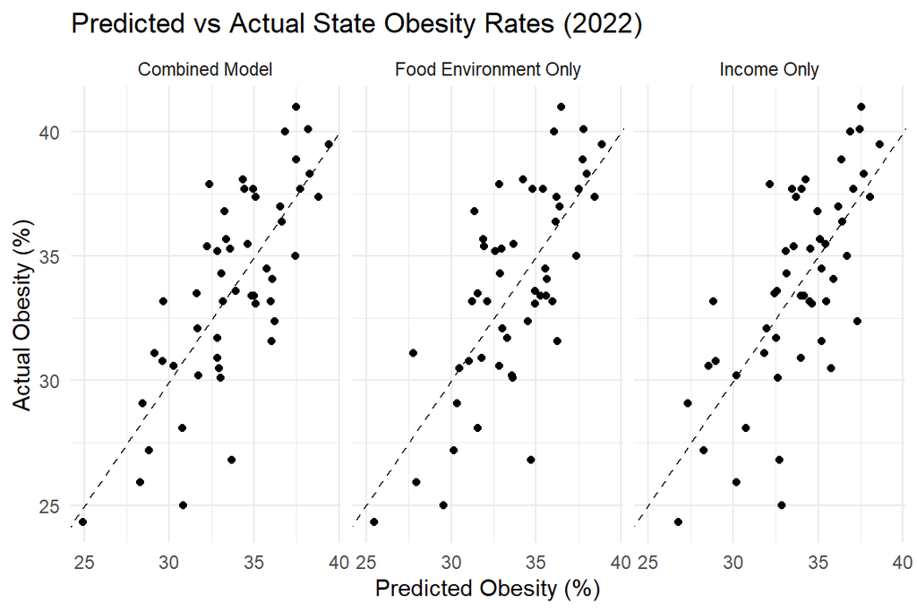

**QUESTION II**

To answer our second question, we studied whether race and age demographics can be used to predict adult obesity rates across U.S. states. This is pivotal as understanding whether these factors predict obesity at the state level, enables us to identify where public health resources may be needed the most. Our goal was to see how much obesity varies with race and age (separately and together) and whether prediction improves when both groups of variables are included in the same model. To start, we used linear regression models because they enabled us to measure the independent contribution of each demographic variable while keeping others constant. Each observation in our dataset represents one U.S. state. For race, we used the percent of the population identifying as White, Black, Hispanic, or Asia. These are all from 2020. For age, we included the percent of residents 18 or younger and the percent of residents 65 or older. This is also from 2020. We created three models as seen below. The first used only race variables, the second used only age variables, and the third combined race and age into a single model.

**Model 1: Race Only**

```
##
## Call:
## lm(formula = PCT_OBESE_ADULTS22 ~ PCT_NHWHITE20 + PCT_NHBLACK20 +
##     PCT_HISP20 + PCT_NHASIAN20, data = state_df2)
##
## Residuals:
##     Min      1Q  Median      3Q     Max
## -9.6281 -1.6377  0.0877  2.3417  5.9684
##
## Coefficients:
##               Estimate Std. Error t value   Pr(>|t|)
## (Intercept)   42.72697    7.89100   5.415 0.00000216 ***
## PCT_NHWHITE20 -0.07731    0.08420  -0.918    0.36336
## PCT_NHBLACK20 -0.01876    0.08359  -0.224    0.82337
## PCT_HISP20    -0.18126    0.09869  -1.837    0.07274 .
## PCT_NHASIAN20 -0.63471    0.21457  -2.958    0.00488 **
## ---
## Signif. codes:  0 '***' 0.001 '**' 0.01 '*' 0.05 '.' 0.1 ' ' 1
##
## Residual standard error: 3.467 on 46 degrees of freedom
## Multiple R-squared:  0.328,  Adjusted R-squared:  0.2696
## F-statistic: 5.613 on 4 and 46 DF,  p-value: 0.0009141
```

The first model above included the percentage of White, Black, Hispanic, and Asian residents in each state. The model explained about 33 percent of the variation in obesity rates `(since R² = 0.328)`. Most race variables were not statistically significant which means they did not exhibit strong evidence of a relationship once the model controlled for other groups. However, we noticed the one exception was the Asian population. This is because states with a higher percentage of Asian residents tended to have lower obesity rates `(as shown by the p-value of p = 0.0049)`. The other race coefficients had weak/inconsistent relationships and large p-values. Thus, this tells us that racial composition alone does not fully explain obesity patterns at the state level (even if Asian percentage appears to have an independent association).

**Model 2: Age Only**

```
##
## Call:
## lm(formula = PCT_OBESE_ADULTS22 ~ PCT_65OLDER20 + PCT_18YOUNGER20,
##     data = state_df2)
##
## Residuals:
##     Min      1Q  Median      3Q     Max
## -7.9795 -2.1321 -0.4434  2.8506  8.2282
##
## Coefficients:
##                 Estimate Std. Error t value Pr(>|t|)
## (Intercept)       6.2845     7.9723   0.788 0.434400
## PCT_65OLDER20     0.3576     0.2449   1.460 0.150742
## PCT_18YOUNGER20   0.9447     0.2438   3.875 0.000323 ***
## ---
## Signif. codes:  0 '***' 0.001 '**' 0.01 '*' 0.05 '.' 0.1 ' ' 1
##
## Residual standard error: 3.603 on 48 degrees of freedom
## Multiple R-squared:  0.2427, Adjusted R-squared:  0.2112
## F-statistic: 7.693 on 2 and 48 DF,  p-value: 0.001265
```

The second model used the percentage of residents who are 65 or older and the percentage who are 18 or younger. This model explained about 24 percent of the variation in obesity rates `(given as R² = 0.242)`. The younger population variable was strongly significant `(p = 0.0003)`. States with more residents under age 18 tend to have higher adult obesity rates. We hypothesize that states with larger family and youth populations might also have environmental or economic conditions linked to higher obesity risk. The older population variable was not significant `(p = 0.1507)`. Overall, age does help predict adult obesity but only through the younger population measure. This model performs slightly worse than the race model but still reveals a pretty meaningful pattern.

**Model 3: Combined Model (Age+Race)**

```
##
## Call:
## lm(formula = PCT_OBESE_ADULTS22 ~ PCT_NHWHITE20 + PCT_NHBLACK20 +
##     PCT_HISP20 + PCT_NHASIAN20 + PCT_65OLDER20 + PCT_18YOUNGER20,
##     data = state_df2)
##
## Residuals:
##     Min      1Q  Median      3Q     Max
## -6.7802 -1.3653  0.0529  1.2631  7.2670
##
## Coefficients:
##                 Estimate Std. Error t value  Pr(>|t|)
## (Intercept)      1.85651   11.47525   0.162    0.8722
## PCT_NHWHITE20   -0.01367    0.07702  -0.177    0.8600
## PCT_NHBLACK20    0.12181    0.07813   1.559    0.1261
## PCT_HISP20      -0.12961    0.08762  -1.479    0.1462
## PCT_NHASIAN20   -0.28549    0.20263  -1.409    0.1659
## PCT_65OLDER20    0.61067    0.24507   2.492    0.0165 *
## PCT_18YOUNGER20  1.00304    0.23405   4.285 0.0000977 ***
## ---
## Signif. codes:  0 '***' 0.001 '**' 0.01 '*' 0.05 '.' 0.1 ' ' 1
##
## Residual standard error: 2.952 on 44 degrees of freedom
## Multiple R-squared:  0.534,  Adjusted R-squared:  0.4704
## F-statistic: 8.403 on 6 and 44 DF,  p-value: 0.000004301
```

To visualize the model performance, we created predicted vs actual plots for all three models. This is very similar to the first question we answered. These are shown below. When the predictions line up close to the dashed 1 to 1 line, the model is doing a good job. The combined model appears closest to the line. The race-only and age-only models have a much looser spread of points. This visual confirms the numerical results from the tables. The combined model gives us the most accurate predictions.

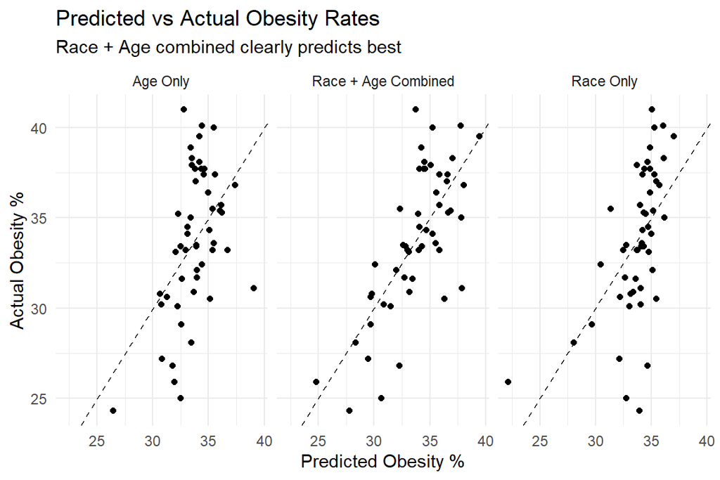

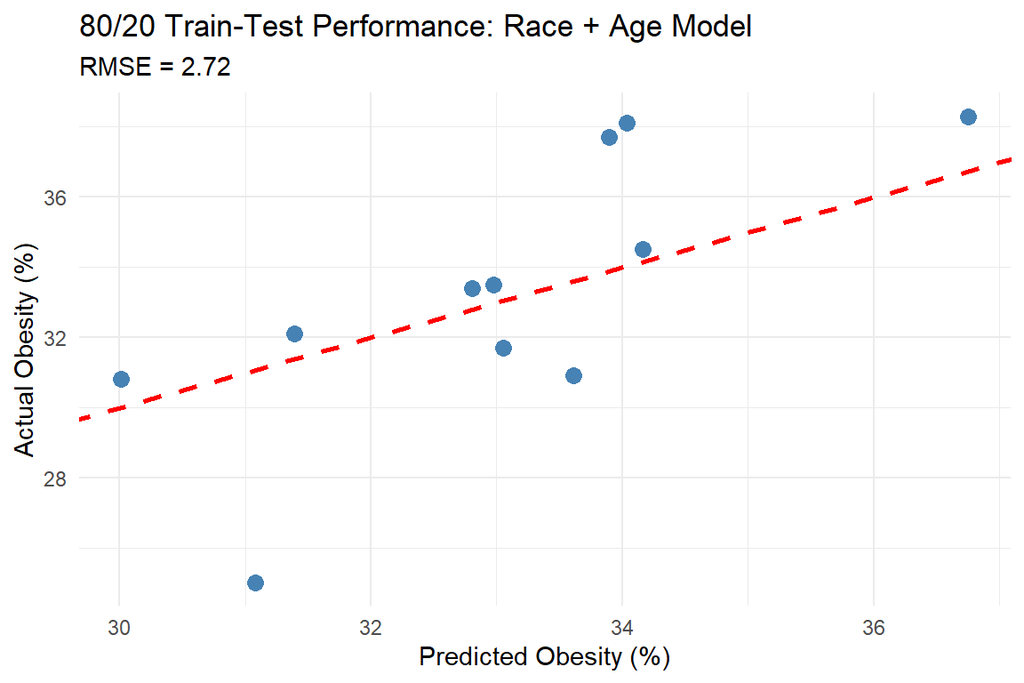

In essence, across all methods, we found that both race and age demographics are decent predictors. Race and age each capture different parts of a state’s population structure. When combined, they produce a stronger and more “complete picture”. The tables and figures in this section show that demographic patterns have real predictive value for understanding obesity at the state level.

# CONCLUSION

Moving forward, it is also important to acknowledge the limitations of the dataset and the simplicity of linear models. Future work could use additional predictors such as health-care access, or education data or use more flexible modeling, which may capture nonlinear patterns that linear regression cannot. Expanding the dataset to include multiple years of obesity trends could also help identify causal pathways rather than associations.